# HW1 - Time series graphics

Rachel Greenlee

2/4/2022

**Exercises from Section 2 of Forecasting: Principles & Practice at https://otexts.com/fpp3/graphics-exercises.html**

### Exercise 2.1

#### Use the help function to explore what the series gafa_stock, PBS, vic_elec and pelt represent.

```r
#?gafa_stock
#?PBS
#?vic_elec
#?pelt
```

#### Use autoplot() to plot some of the series in these data sets.

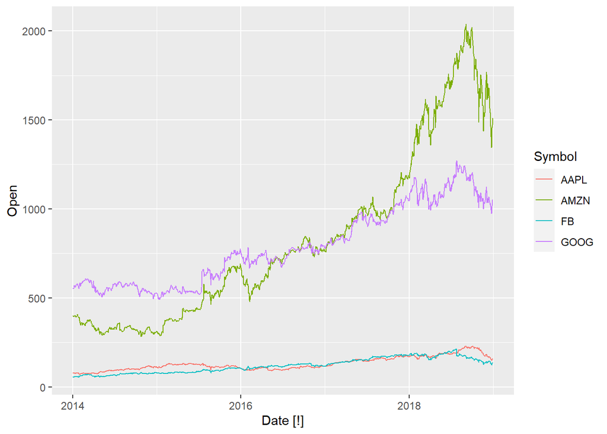

```r
autoplot(gafa_stock)
```

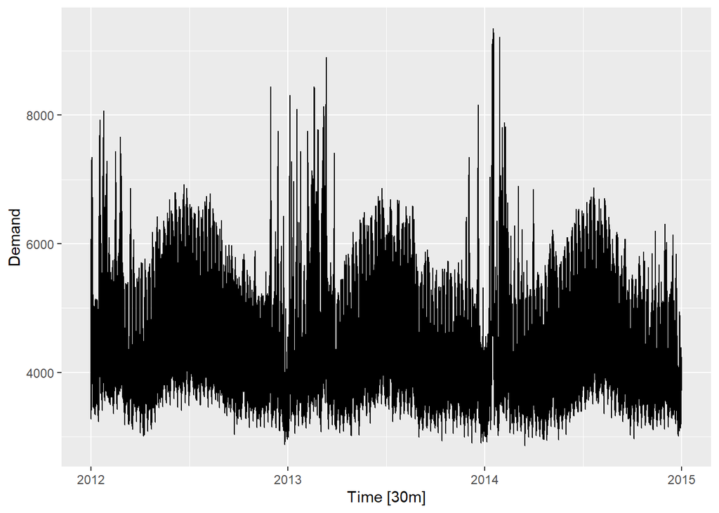

```r
autoplot(vic_elec)
```

#### What is the time interval of each series?

`gafa_stock` is daily, with the omission of weekends and federal holidays  
`PBS` is monthly  
`vic_elec` is in half-hour (30 minute) increments  
`pelt` is annual

### Exercise 2.2

#### Use filter() to find what days corresponded to the peak closing price for each of the four stocks in gafa_stock.

```r
gafa_stock %>%
  group_by(Symbol) %>%
  filter(Close == max(Close))
```

```
## # A tsibble: 4 x 8 [!]
## # Key:       Symbol [4]
## # Groups:    Symbol [4]
##   Symbol Date        Open  High   Low Close Adj_Close   Volume
##   <chr>  <date>     <dbl> <dbl> <dbl> <dbl>     <dbl>    <dbl>
## 1 AAPL   2018-10-03  230.  233.  230.  232.      230. 28654800
## 2 AMZN   2018-09-04 2026. 2050. 2013  2040.     2040.  5721100
## 3 FB     2018-07-25  216.  219.  214.  218.      218. 58954200
## 4 GOOG   2018-07-26 1251  1270. 1249. 1268.     1268.  2405600
```

### Exercise 2.3

#### Download the file tute1.csv from the book website, open it in Excel (or some other spreadsheet application), and review its contents. You should find four columns of information. Columns B through D each contain a quarterly series, labelled Sales, AdBudget and GDP. Sales contains the quarterly sales for a small company over the period 1981-2005. AdBudget is the advertising budget and GDP is the gross domestic product. All series have been adjusted for inflation.

#### You can read the data into R with the following script:

```r
tute1 <- readr::read_csv("tute1.csv")
#View(tute1)
```

#### Convert the data to time series

```r
#formatting as a tsibble
mytimeseries <- tute1 %>%
  mutate(Quarter = yearmonth(Quarter)) %>%
  as_tsibble(index = Quarter)
```

#### Construct time series plots of each of the three series

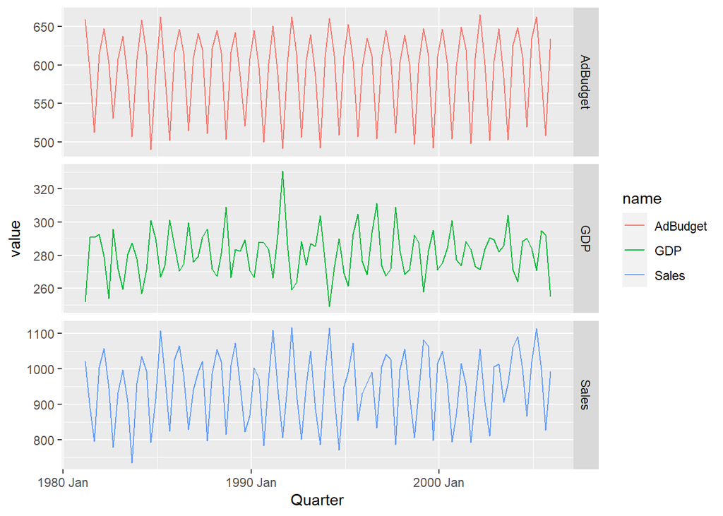

```r
mytimeseries %>%
  pivot_longer(-Quarter) %>%
  ggplot(aes(x = Quarter, y = value, colour = name)) +
  geom_line() +
  facet_grid(name ~ ., scales = "free_y")
```

#### Check what happens when you don’t include facet_grid().

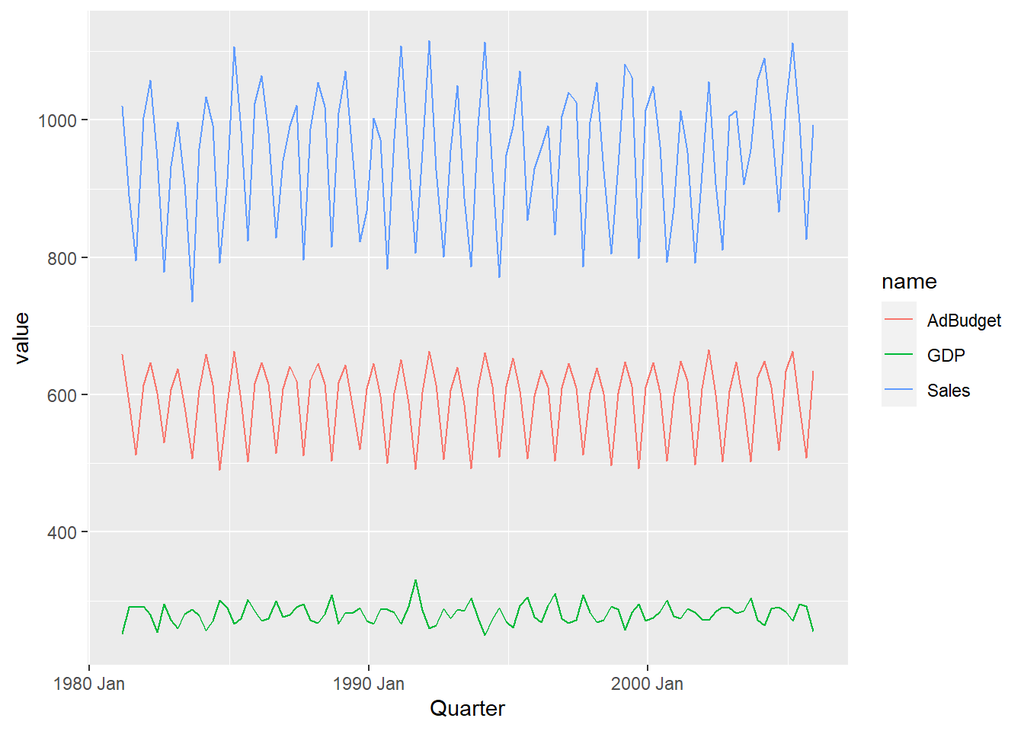

```r
mytimeseries %>%
  pivot_longer(-Quarter) %>%
  ggplot(aes(x = Quarter, y = value, colour = name)) +
  geom_line()
```

### Exercise 2.4

#### The USgas package contains data on the demand for natural gas in the US. Install the USgas package. Create a tsibble from us_total with year as the index and state as the key.

```r
library("USgas")

usgas <- us_total %>%
  tsibble(
  key = state,
  index = year
)
```

#### Plot the annual natural gas consumption by state for the New England area (comprising the states of Maine, Vermont, New Hampshire, Massachusetts, Connecticut and Rhode Island).

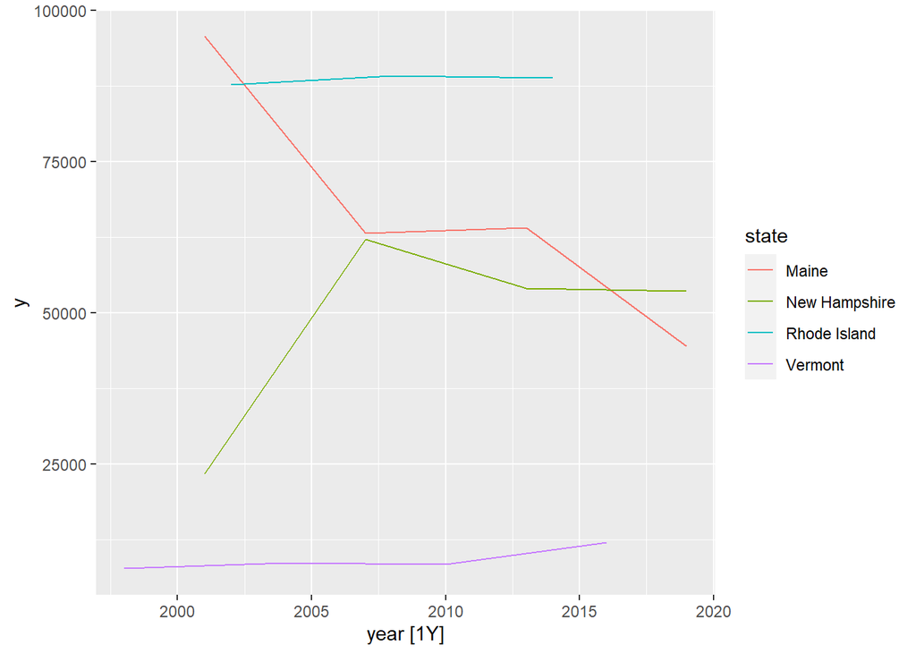

```r
autoplot(usgas %>%
           filter(state == c("Maine", "Vermont", "New Hampshire", "massachusetts", "conneticut", "Rhode Island")))
```

### Exercise 2.5

#### Download tourism.xlsx from the book website and read it into R using readxl::read_excel(). Create a tsibble which is identical to the tourism tsibble from the tsibble package.

```r
tourism_raw <- readxl::read_excel("tourism.xlsx")

# make date class
tourism_raw$Quarter <- as.Date(tourism_raw$Quarter, "%Y-%m-%d")
# put in yyyy qq format
tourism_raw$Quarter <- yearquarter(tourism_raw$Quarter)

# put into tsibble
tourism_2 <- tourism_raw %>%
  tsibble(key = c(Region, State, Purpose, Trips),
  index = Quarter
)

# check tsibble from package to compare
#view(tourism)
```

#### Find what combination of Region and Purpose had the maximum number of overnight trips on average.

```r
# select needed variables, group by prompt, add trips_avg variable,
# drop Trips so you can de-dupe, then arrange by trips_avg in descending order
tourism_raw %>%
  select(c(Region, Purpose, Trips)) %>%
  group_by(Region, Purpose) %>%
  mutate(trips_avg = mean(Trips)) %>%
  select(-Trips) %>%
  distinct() %>%
  arrange(desc(trips_avg))
```

```
## # A tibble: 304 x 3
## # Groups:   Region, Purpose [304]
##    Region          Purpose  trips_avg
##    <chr>           <chr>        <dbl>
##  1 Sydney          Visiting      747.
##  2 Melbourne       Visiting      619.
##  3 Sydney          Business      602.
##  4 North Coast NSW Holiday       588.
##  5 Sydney          Holiday       550.
##  6 Gold Coast      Holiday       528.
##  7 Melbourne       Holiday       507.
##  8 South Coast     Holiday       495.
##  9 Brisbane        Visiting      493.
## 10 Melbourne       Business      478.
## # ... with 294 more rows
```

#### Create a new tsibble which combines the Purposes and Regions, and just has total trips by State.

```r
tourism_states <- tourism_raw %>%
  select(c(Region, Purpose, Trips, State, Quarter)) %>%
  group_by(State, Quarter) %>%
  mutate(purpose_region = paste(Purpose, "-", Region),
         state_tot_trips = sum(Trips)) %>%
  select(-c(Region, Purpose, Trips)) %>%
  distinct() %>%
  as_tsibble(key = c(State, purpose_region),
             index = Quarter)

head(tourism_states)
```

```
## # A tsibble: 6 x 4 [1Q]
## # Key:       State, purpose_region [1]
## # Groups:    State @ Quarter [6]
##   State Quarter purpose_region      state_tot_trips
##   <chr>   <qtr> <chr>                         <dbl>
## 1 ACT   1998 Q1 Business - Canberra            551.
## 2 ACT   1998 Q2 Business - Canberra            416.
## 3 ACT   1998 Q3 Business - Canberra            436.
## 4 ACT   1998 Q4 Business - Canberra            450.
## 5 ACT   1999 Q1 Business - Canberra            379.
## 6 ACT   1999 Q2 Business - Canberra            558.
```